# 1. Linear Regression

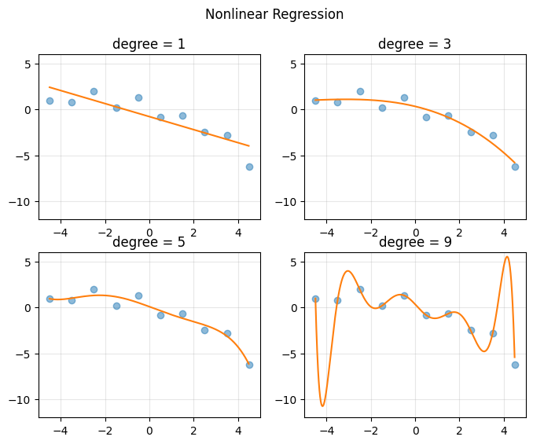

```python
d = [1, 3, 5, 9]
RSS = []

plt.figure(figsize = (8, 6))
plt.suptitle('Nonlinear Regression', fontsize = 12)

for k in range(4):
    A = np.hstack([x**i for i in range(d[k]+1)])
    polybasis = np.hstack([xp**i for i in range(d[k]+1)])

    A = np.asmatrix(A)
    polybasis = np.asmatrix(polybasis)

    theta = (A.T*A).I*A.T*y
    yp = polybasis*theta

    RSS.append(np.linalg.norm(y - A*theta, 2)**2)

    plt.subplot(2, 2, k+1)
    plt.plot(x, y, 'o', alpha = 0.5)
    plt.plot(xp, yp)
    plt.axis([-5, 5, -12, 6])
    plt.title('degree = {}'.format(d[k]))
    plt.grid(alpha=0.3)

plt.show()
```

Residual Sum of Squares

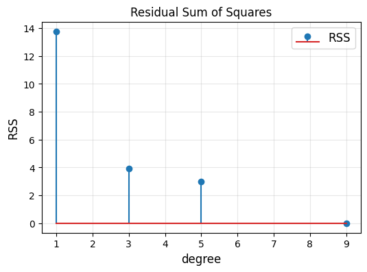

```python
plt.figure(figsize = (6, 4))
plt.stem(d, RSS, label = 'RSS')
plt.title('Residual Sum of Squares', fontsize = 12)
plt.xlabel('degree', fontsize = 12)
plt.ylabel('RSS', fontsize = 12)
plt.legend(fontsize = 12)
plt.grid(alpha = 0.3)
plt.show()
```

Residual Sum of Squares (RSS) decreases as the polynomial degree increases. A 9th-order polynomial regression applied to a dataset with 10 data points will result in zero RSS. However, a lower error does not necessarily indicate a better model, as overfitting may compromise generalization.

**Key Takeaways**

- Underfitting: Happens when the model is too simple (e.g., a low-degree polynomial) and fails to capture the pattern.
- Good Fit: Achieved when the model is complex enough to capture the trend but not so flexible that it fits noise.
- Overfitting: Happens when the model is too complex (e.g., a high-degree polynomial) and memorizes noise, reducing generalization.

By testing different degrees of polynomial functions, this example demonstrates the importance of finding the right balance between model complexity and generalization to avoid underfitting and overfitting.

We will repeat the same case to build a nonlinear regression model using RBF functions.

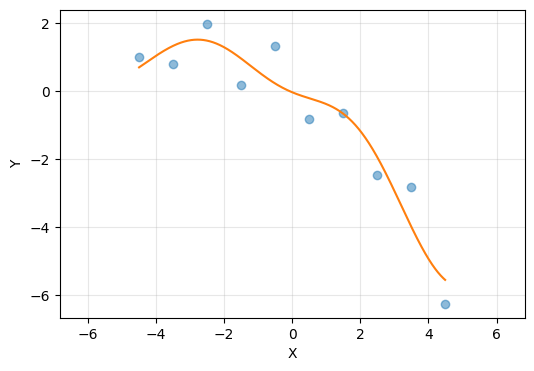

```python
xp = np.arange(-4.5, 4.5, 0.01).reshape(-1, 1)

d = 5
u = np.linspace(-4.5, 4.5, d)
sigma = 2

A = np.hstack([np.exp(-(x-u[i])**2/(2*sigma**2)) for i in range(d)])
rbfbasis = np.hstack([np.exp(-(xp-u[i])**2/(2*sigma**2)) for i in range(d)])

A = np.asmatrix(A)
rbfbasis = np.asmatrix(rbfbasis)

theta = (A.T*A).I*A.T*y
yp = rbfbasis*theta

plt.figure(figsize = (6, 4))
plt.plot(x, y, 'o', alpha = 0.5)
plt.plot(xp, yp)
plt.xlabel('X')
plt.ylabel('Y')
plt.grid(alpha = 0.3)
plt.axis('equal')
plt.show()
```

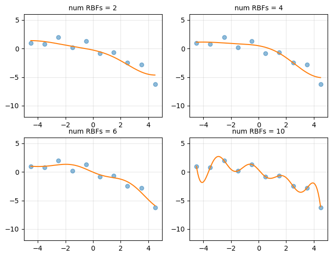

```python
d = [2, 4, 6, 10]
sigma = 2

plt.figure(figsize = (8, 6))

for k in range(4):
    u = np.linspace(-4.5, 4.5, d[k])

    A = np.hstack([np.exp(-(x-u[i])**2/(2*sigma**2)) for i in range(d[k])])
    rbfbasis = np.hstack([np.exp(-(xp-u[i])**2/(2*sigma**2)) for i in range(d[k])])

    A = np.asmatrix(A)
    rbfbasis = np.asmatrix(rbfbasis)

    theta = (A.T*A).I*A.T*y
    yp = rbfbasis*theta

    plt.subplot(2, 2, k+1)
    plt.plot(x, y, 'o', alpha = 0.5)
    plt.plot(xp, yp)
    plt.axis([-5, 5, -12, 6])
    plt.title('num RBFs = {}'.format(d[k]), fontsize = 10)
    plt.grid(alpha = 0.3)

plt.show()
```

## 4.2. Overfitting

Overfitting occurs when a machine learning model performs well on the training data but poorly on unseen or test data. The model essentially "memorizes" the noise and details in the training set rather than learning the general patterns that can be applied to new data.

**Overfitting Problem**

- Have you come across a situation where your model performed exceptionally well on train data, but was not able to predict test data?
- One of the most common problem data science professionals face is to avoid overfitting.

**Causes of Overfitting**

- Model Complexity: A model with too many parameters (e.g., deep neural networks) can overfit the training data.
- Insufficient Training Data: If the training dataset is small, the model may fit every point precisely, capturing noise rather than general patterns.
- Noisy Data: If the data has a lot of noise or irrelevant features, the model may try to learn this noise.
- Too Many Training Iterations: Training for too long can lead to overfitting, where the model starts fitting noise instead of actual patterns.

**Signs of Overfitting**

- High Training Accuracy, Low Test Accuracy: The model performs well on the training set but poorly on the validation/test set.
- Large Gap Between Training and Validation Loss: Training loss continues to decrease, but validation loss increases.

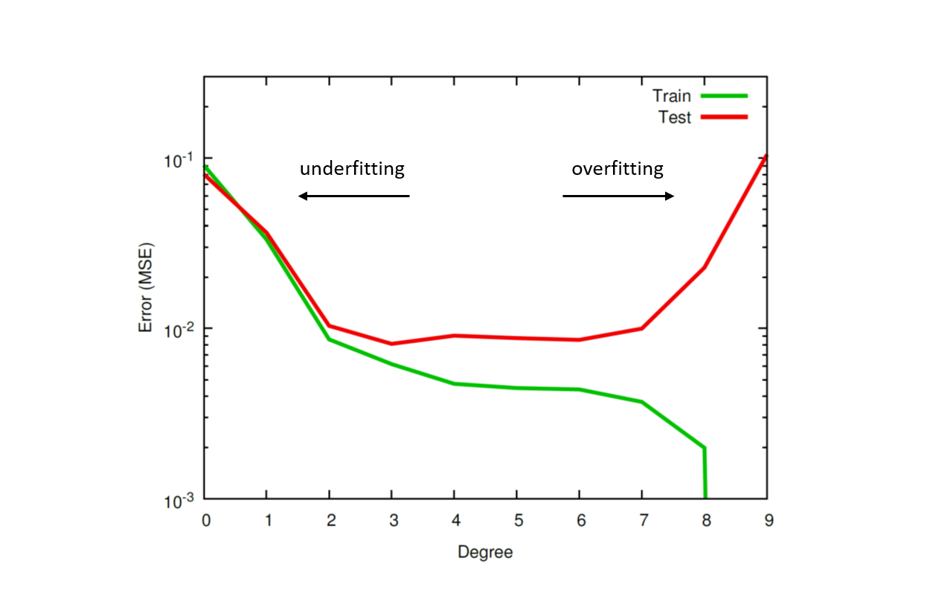

**Generalization Error**

Generalization Error refers to the difference between a machine learning model's performance on the training data and its performance on unseen data (test or validation data). In other words, the generalization error measures the difference between the expected loss on unseen test data and the loss on the training data. It measures how well the model can generalize to new, unseen examples. A model with a low generalization error performs well not only on the training set but also on new data.

Mathematically, the generalization error can be defined as:

$$ \text{Generalization Error} = \mathbb{E}_{D_{\text{test}}}[\mathcal{L}(f(x), y)] - \mathbb{E}_{D_{\text{train}}}[\mathcal{L}(f(x), y)], $$

where:

- $D_{\text{test}}$ and $D_{\text{train}}$ are the test and training data distributions.
- $f(x)$ is the model's prediction function.
- $\mathcal{L}(f(x), y)$ is the loss function measuring the difference between the predicted and true values.

**Techniques to Prevent Overfitting**

(1) Regularization

- Prevent overfitting by adding a penalty to the loss function, encouraging simpler models with smaller weights.
- This penalty discourages the model from fitting noise in the training data by constraining the values of the model's parameters.
- Regularization helps the model generalize better to unseen data by making it simpler and less sensitive to outliers.

(2) Early Stopping

- Monitors the validation loss during training and stops when the loss starts increasing to prevent overfitting.

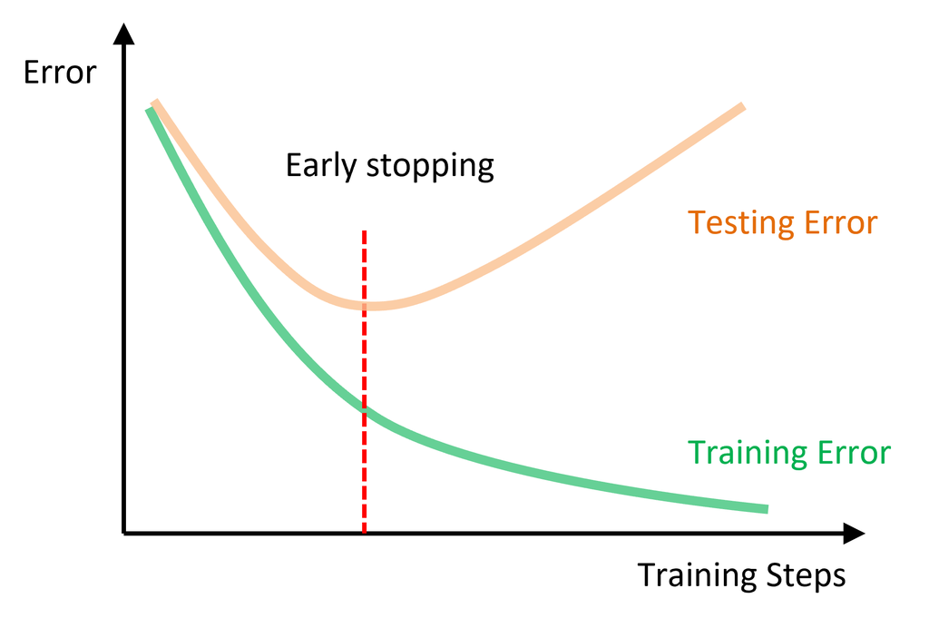

(3) Data Augmentation

- Increases the training set size by applying transformations (e.g., rotations, flips, cropping) to existing data, making the model more generalizable.

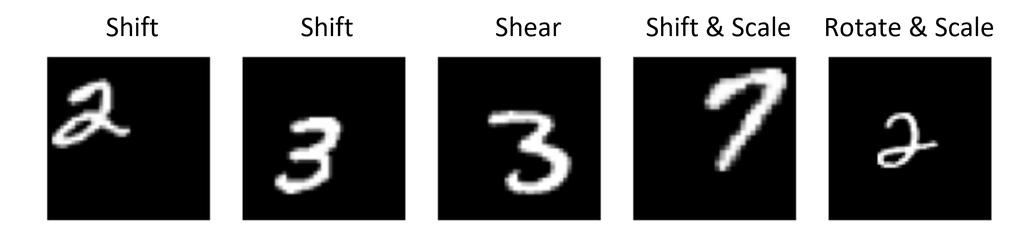

(4) Cross-Validation

- Splits the data into multiple folds to train and validate the model on different subsets, ensuring that the model is not overfitting specific subsets of data.

(5) Reduce Model Complexity

- Use simpler models with fewer parameters to avoid memorizing the training data.

Among the various techniques to prevent overfitting, the regularization method will be the primary focus of the following session.

## 4.3. Regularization to Reduce Overfitting

L2 regularization, also known as Ridge Regularization or weight decay, involves adding a penalty equal to the sum of the squared weights to the loss function. It discourages large weights by penalizing their size, helping the model learn simpler and more robust patterns. Often, overfitting associated with very large estimated parameters $\theta$.

We want to balance

- how well function fits data
- magnitude of coefficients

$$ \begin{align*} \text{Total cost } = \;&\underbrace{\text{measure of fit}}_{RSS(\theta)} + \;\lambda \cdot \underbrace{\text{measure of magnitude of coefficients}}_{\lambda \cdot \lVert \theta \rVert_2^2} \\ \\ \implies &\min\; \lVert \Phi \theta - y \rVert_2^2 + \lambda \lVert \theta \rVert_2^2 \end{align*} $$

Where

- the first term, $ RSS(\theta) = \lVert \Phi\theta - y \rVert^2_2 $ (= Rresidual Sum of Squares)
- the second term, $\lambda \cdot \lVert \theta \rVert_2^2$, called a shrinkage penalty, is small when $\theta_1, \cdots,\theta_d$ are close to zeros, and so it has the effect of shrinking the estimates of $\theta_j$ towards zero
- The tuning parameter $\lambda$ serves to control the relative impact of these two terms on the regression coefficient estimates
- known as a *ridge regression*

**How L2 Regularization Works**

- Effect on Weights:
  - L2 regularization forces the model to keep weights small.
- Interpretation:
  - L2 regularization distributes the penalty uniformly across all weights, shrinking their magnitude.
- Overfitting Reduction:
  - By limiting the model's ability to learn large weights, the model becomes less likely to overfit the noise in the training data.

**Example**:

Start with a rich representation

$$\min\; \lVert \Phi \theta - y \rVert_2^2$$

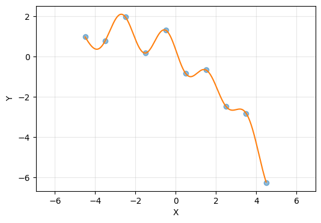

```python
# CVXPY code

import cvxpy as cvx

d = 10
u = np.linspace(-4.5, 4.5, d)

sigma = 1

A = np.hstack([np.exp(-(x-u[i])**2/(2*sigma**2)) for i in range(d)])
rbfbasis = np.hstack([np.exp(-(xp-u[i])**2/(2*sigma**2)) for i in range(d)])

A = np.asmatrix(A)
rbfbasis = np.asmatrix(rbfbasis)

theta = cvx.Variable([d, 1])
obj = cvx.Minimize(cvx.sum_squares(A@theta - y))
prob = cvx.Problem(obj).solve()

yp = rbfbasis*theta.value

plt.figure(figsize = (6, 4))
plt.plot(x, y, 'o', alpha = 0.5)
plt.plot(xp, yp)
plt.xlabel('X')
plt.ylabel('Y')
plt.axis([-5, 5, -12, 6])
plt.grid(alpha = 0.3)
plt.axis('equal')
plt.show()
```

As observed in the graph above, using 10 RBF functions for 10 data points results in a perfect fit, achieving zero RSS for the training data. However, this clearly indicates overfitting.

Visualizing the learned coefficients of a regression model is a valuable step in understanding the influence of each basis.

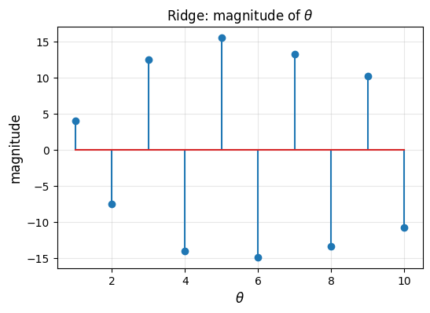

```python
plt.figure(figsize = (6, 4))
plt.title(r'Ridge: magnitude of $\theta$', fontsize = 12)
plt.xlabel(r'$\theta$', fontsize = 12)
plt.ylabel('magnitude', fontsize = 12)
plt.stem(np.linspace(1, 10, 10).reshape(-1, 1), theta.value)
plt.xlim([0.5, 10.5])
# plt.ylim([-5, 5])
plt.grid(alpha = 0.3)
plt.show()
```

Then, regularize coefficients $\theta$

$$\min\; \lVert \Phi \theta - y \rVert_2^2 + \lambda \lVert \theta \rVert_2^2$$

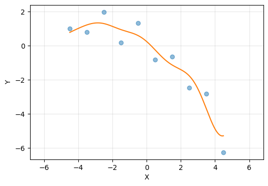

```python
# ridge regression

lamb = 0.1

theta = cvx.Variable([d, 1])
obj = cvx.Minimize(cvx.sum_squares(A@theta - y) + lamb*cvx.sum_squares(theta))
prob = cvx.Problem(obj).solve()

yp = rbfbasis*theta.value

plt.figure(figsize = (6, 4))
plt.plot(x, y, 'o', alpha = 0.5)
plt.plot(xp, yp, label = 'Ridge')
plt.xlabel('X')
plt.ylabel('Y')
plt.axis([-5, 5, -12, 6])
plt.grid(alpha = 0.3)
plt.axis('equal')
plt.show()
```

Plot the values of all the coefficients.

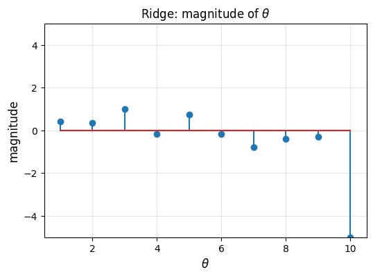

```python
# Regulization (= ridge nonlinear regression) encourages small weights, but not exactly 0

plt.figure(figsize = (6, 4))
plt.title(r'Ridge: magnitude of $\theta$', fontsize = 12)
plt.xlabel(r'$\theta$', fontsize = 12)
plt.ylabel('magnitude', fontsize = 12)
plt.stem(np.linspace(1, 10, 10).reshape(-1, 1), theta.value)
plt.xlim([0.5, 10.5])
plt.ylim([-5, 5])
plt.grid(alpha = 0.3)
plt.show()
```

Larger $\lambda$ forces the model to keep weights small.

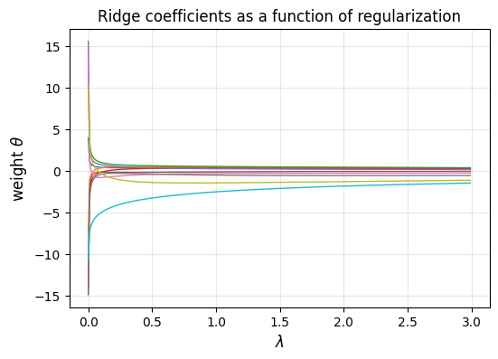

```python
lamb = np.arange(0, 3, 0.01)

theta_record = []
for k in lamb:
    theta = cvx.Variable([d, 1])
    obj = cvx.Minimize(cvx.sum_squares(A@theta - y) + k*cvx.sum_squares(theta))
    prob = cvx.Problem(obj).solve()
    theta_record.append(np.ravel(theta.value))

plt.figure(figsize = (6, 4))
plt.plot(lamb, theta_record, linewidth = 1)
plt.title('Ridge coefficients as a function of regularization', fontsize = 12)
plt.xlabel('$\lambda$', fontsize = 12)
plt.ylabel(r'weight $\theta$', fontsize = 12)
plt.grid(alpha = 0.3)
plt.show()
```

From this example, we learn that regularization, specifically ridge regression, can be an effective method for overcoming overfitting challenges.

## 4.4. Sparsity for Feature Selection using LASSO

Ridge regression applies a penalty on the magnitude of the weights using the L2 norm. Why not consider using the L1 norm instead?

Try this cost instead of ridge...

$$ \begin{align*} \text{Total cost } = \;&\underbrace{\text{measure of fit}}_{RSS(\theta)} + \;\lambda \cdot \underbrace{\text{measure of magnitude of coefficients}}_{\lambda \cdot \lVert \theta \rVert_1} \\ \\ \implies &\min\; \lVert \Phi \theta - y \rVert_2^2 + \lambda \lVert \theta \rVert_1 \end{align*}$$

Consider the same problem but with a different objective function:

$$\min\; \lVert \Phi \theta - y \rVert_2^2 + \lambda \lVert \theta \rVert_1$$

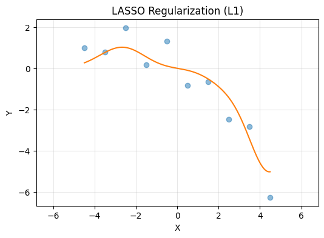

```python
# LASSO regression

lamb = 2
theta = cvx.Variable([d, 1])
obj = cvx.Minimize(cvx.sum_squares(A@theta - y) + lamb*cvx.norm(theta, 1))
prob = cvx.Problem(obj).solve()

yp = rbfbasis*theta.value

plt.figure(figsize = (6, 4))
plt.title('LASSO Regularization (L1)', fontsize = 12)
plt.xlabel('X')
plt.ylabel('Y')
plt.plot(x, y, 'o', alpha = 0.5)
plt.plot(xp, yp)
plt.axis([-5, 5, -12, 6])
plt.grid(alpha = 0.3)
plt.axis('equal')
plt.show()
```

By selecting an appropriate value for $ \lambda $, the above example demonstrates that the L1 norm can also effectively mitigate overfitting.

This naturally leads to the consideration of the differences between L2 and L1 regularization techniques.

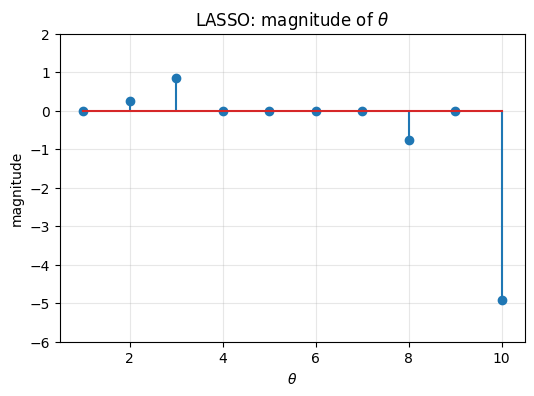

```python
# Regulization (= Lasso nonlinear regression) encourages zero weights

plt.figure(figsize = (6, 4))
plt.title(r'LASSO: magnitude of $\theta$', fontsize = 12)
plt.xlabel(r'$\theta$')
plt.ylabel('magnitude')
plt.stem(np.arange(1,11), theta.value)
plt.xlim([0.5, 10.5])
plt.ylim([-6, 2])
plt.grid(alpha = 0.3)
plt.show()
```

The L1 penalty (used in Lasso Regression) has the unique property of:

- Shrinking some coefficients exactly to 0
- This effectively removes certain features from the model.
- In other words, it performs automatic feature selection.

As a result:

- Only features with non-zero coefficients are considered important or selected by the model.
- This leads to sparser, more interpretable models, especially useful when dealing with high-dimensional data.

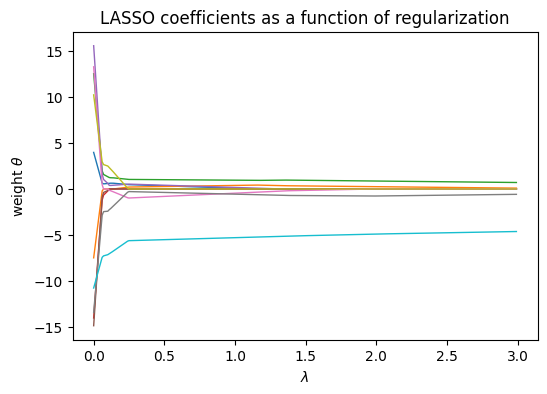

```python
lamb = np.arange(0, 3, 0.01)

theta_record = []
for k in lamb:
    theta = cvx.Variable([d, 1])
    obj = cvx.Minimize(cvx.sum_squares(A@theta - y) + k*cvx.norm(theta, 1))
    prob = cvx.Problem(obj).solve()
    theta_record.append(np.ravel(theta.value))

plt.figure(figsize = (6, 4))
plt.plot(lamb, theta_record, linewidth = 1)
plt.title('LASSO coefficients as a function of regularization', fontsize = 12)
plt.xlabel('$\lambda$')
plt.ylabel(r'weight $\theta$')
plt.show()
```

**Sparsity and Feature Selection**:

The L1 penalty in LASSO (Least Absolute Shrinkage and Selection Operator) encourages sparsity in the coefficient estimates, meaning it drives some coefficients to be exactly zero. This property is particularly useful for feature selection, as it allows the model to identify and retain only the most relevant predictors, simplifying the model and potentially improving interpretability.

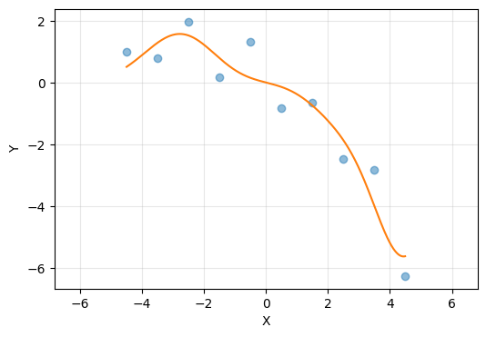

```python
# reduced order model
# we will use only theta 2, 3, 8, 10

d = 4
u = np.array([-3.5, -2.5, 2.5, 4.5])

sigma = 1

A = np.hstack([np.exp(-(x-u[i])**2/(2*sigma**2)) for i in range(d)])
rbfbasis = np.hstack([np.exp(-(xp-u[i])**2/(2*sigma**2)) for i in range(d)])

A = np.asmatrix(A)
rbfbasis = np.asmatrix(rbfbasis)

theta = cvx.Variable([d, 1])
obj = cvx.Minimize(cvx.norm(A@theta - y, 2))
prob = cvx.Problem(obj).solve()

yp = rbfbasis*theta.value

plt.figure(figsize = (6, 4))
plt.plot(x, y, 'o', alpha = 0.5)
plt.plot(xp, yp)
plt.xlabel('X')
plt.ylabel('Y')
plt.axis([-5, 5, -12, 6])
plt.grid(alpha = 0.3)
plt.axis('equal')
plt.show()
```

We numerically demonstrated that the L1 penalty enforces sparsity in the coefficient estimates. But why does this occur?

To better understand this phenomenon, we can explore alternative but equivalent optimization formulations for both Ridge and LASSO regression.

$$ \begin{array}{rl} \begin{align*} \min_{\theta} \quad & \lVert \Phi \theta - y \rVert_2^2 \\ \text{subject to} \quad & \lVert \theta \rVert_{\color{red}1} \leq s_1 \end{align*} \end{array} \quad\quad\quad\quad \begin{array}{rl} \min_{\theta} \; & \lVert \Phi \theta - y \rVert_2^2 \\ \text{subject to} \; & \lVert \theta \rVert_{\color{red}2} \leq s_2 \end{array} $$

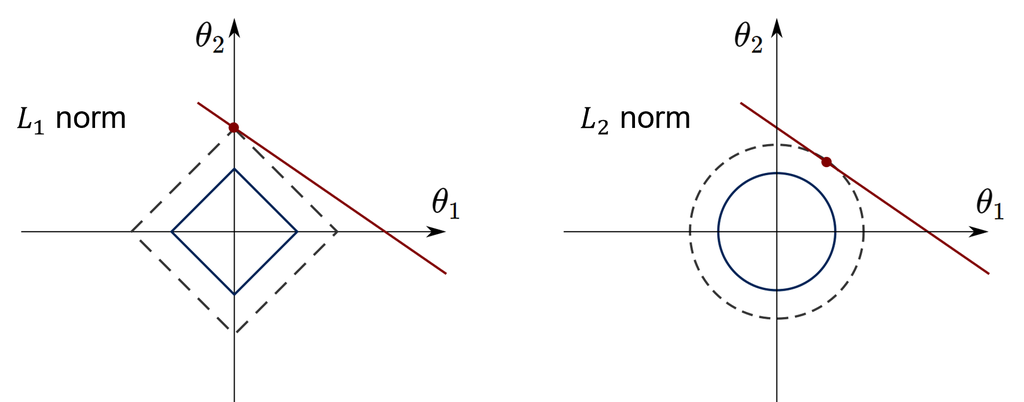

These constrained formulations reveal the underlying geometric properties of L1 and L2 regularization. The L1 constraint encourages solutions where some coefficients are exactly zero, resulting in sparse parameter estimates. In contrast, the L2 constraint tends to shrink all coefficients uniformly, rarely producing exact zeros but effectively controlling overall model complexity.

## 4.5. Scikit-Learn

```python
# 10 data points

n = 10
x = np.linspace(-4.5, 4.5, 10).reshape(-1, 1)
y = np.array([0.9819, 0.7973, 1.9737, 0.1838, 1.3180, -0.8361, -0.6591, -2.4701, -2.8122, -6.2512]).reshape(-1, 1)

d = 10
u = np.linspace(-4.5, 4.5, d)

sigma = 1
A = np.hstack([np.exp(-(x-u[i])**2/(2*sigma**2)) for i in range(d)])
```

```python
from sklearn import linear_model

reg = linear_model.Ridge(alpha = 0.1)
reg.fit(A,y)
```

```
Ridge(alpha=0.1)
```

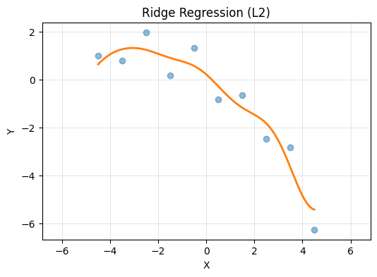

```python
# to plot

xp = np.arange(-4.5, 4.5, 0.01).reshape(-1, 1)
Ap = np.hstack([np.exp(-(xp-u[i])**2/(2*sigma**2)) for i in range(d)])

plt.figure(figsize = (6, 4))
plt.plot(x, y, 'o', alpha = 0.5)
plt.plot(xp, reg.predict(Ap), linewidth = 2, label = "Ridge")
plt.title('Ridge Regression (L2)', fontsize = 12)
plt.xlabel('X')
plt.ylabel('Y')
plt.grid(alpha = 0.3)
plt.axis('equal')
plt.show()
```

```python
reg = linear_model.Lasso(alpha = 0.005)
reg.fit(A,y)
```

```
Lasso(alpha=0.005)
```

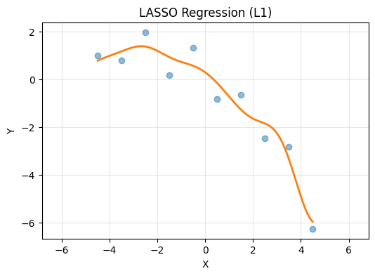

```python
# to plot

xp = np.arange(-4.5, 4.5, 0.01).reshape(-1, 1)
Ap = np.hstack([np.exp(-(xp-u[i])**2/(2*sigma**2)) for i in range(d)])

plt.figure(figsize = (6, 4))
plt.plot(x, y, 'o', alpha = 0.5)
plt.plot(xp, reg.predict(Ap), linewidth = 2, label = "LASSO")
plt.title('LASSO Regression (L1)', fontsize = 12)
plt.xlabel('X')
plt.ylabel('Y')
plt.grid(alpha = 0.3)
plt.axis('equal')
plt.show()
```

We have covered the essential concepts of regression, including both theory and implementation. Now, we will explore additional examples of regression.

# 5. Example: De-noising Signal

We start with a signal represented by a vector $x \in \mathbb{R}^n$. The coefficients $x_i$ correspond to the value of some function of time, evaluated (or *sampled*, in the language of signal processing) at evenly spaced points. It is usually assumed that the signal does not vary too rapidly, which means that usually, we have $x_i \approx x_{i+1}$.

Suppose we have a signal $x$, which does not vary too rapidly and that $x$ is corrupted by some small, rapidly varying noise $\varepsilon$, i.e., $x_{\text{cor}} = x + \varepsilon$.

Then if we want to reconstruct $x$ from $x_{\text{cor}}$ we should solve (with $\hat{x}$ as the parameter)

$$ \text{minimize} \quad \lVert \hat{x} - x_{\text{cor}}\rVert_2^2 + \mu\sum_{i=1}^{n-1}(x_{i+1}-x_i)^2 $$

where the parameter $\mu$ controls the ''smoothnes'' of $\hat{x}$.

Source:

- Boyd & Vandenberghe's book "[Convex Optimization](http://stanford.edu/~boyd/cvxbook/)"
- http://cvxr.com/cvx/examples/ (Figures 6.8-6.10: Quadratic smoothing)
- Week 4 of Linear and Integer Programming by [Coursera](https://www.coursera.org/) of Univ. of Colorado

```python
import numpy as np
import matplotlib.pyplot as plt
import cvxpy as cvx

%matplotlib inline
```

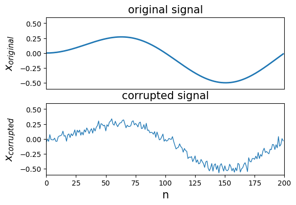

```python
n = 200
t = np.arange(n).reshape(-1,1)
x = 0.5 * np.sin((2*np.pi/n)*t) * (np.sin(0.01*t))
x_cor = x + 0.05*np.random.randn(n,1)

plt.figure(figsize = (6, 4))
plt.subplot(2,1,1)
plt.plot(t,x,'-', linewidth = 2)
plt.axis([0, n, -0.6, 0.6])
plt.xticks([])
plt.title('original signal' , fontsize = 15)
plt.ylabel('$x_{original}$', fontsize = 15)

plt.subplot(2,1,2)
plt.plot(t, x_cor,'-', linewidth = 1)
plt.axis([0, n, -0.6, 0.6])
plt.title('corrupted signal', fontsize = 15)
plt.xlabel('n', fontsize = 15)
plt.ylabel('$x_{corrupted}$', fontsize = 15)
plt.show()
```

## 5.1. Transforming Denoising in Time into an Optimization Problem

We represent the signal as a column vector:

$$X = \begin{bmatrix} x_{1} \\ x_{2} \\ \vdots \\ x_{n} \end{bmatrix} $$

We aim to recover a smooth and denoised version of the signal $X$, given a corrupted version $X_{\text{cor}}$. This can be framed as an optimization problem:

$$\large \min\limits_{X}\;\left\{\underbrace{\lVert(X - X_{\text{cor}})\rVert^2_{2}}_{\text{how much } X \text{ deviates from }X_{\text{cor}}} + \mu \underbrace{\sum_{k = 1}^{n-1}(x_{k+1}-x_{k})^2}_{\text{penalize rapid changes of } X}\right\}$$

(1) Fidelity Term:

$$\min_{X}\;\lVert(X - X_{\text{cor}})\rVert^2_{2}$$

$\quad \;$This term ensures the recovered signal stays close to the original (possibly noisy) observations.

(2) Smoothness Term

$$\sum_{k = 1}^{n-1}(x_{k+1}-x_{k})^2$$

$\quad \;$This term penalizes rapid changes in the signal, encouraging smooth transitions from one time point to the next.

(3) $\mu$ : to adjust the relative weight of (1) & (2)

**Vectorizing the Denoising Optimization Problem**

To solve the denoising problem efficiently, we express both components of the cost function in vector-matrix form.

(1) $X - X_{\text{cor}} = I_n X - X_{\text{cor}}$

(2) $\sum\;(x_{k+1}-x_{k})^2 \implies$

$$(x_{2} - x_{1}) - 0 = \begin{bmatrix} -1,&1,&0,&\cdots&0 \end{bmatrix} \begin{bmatrix} x_{1} \\ x_{2} \\ \vdots \\ x_{n} \end{bmatrix}-0 $$

$$(x_{3} - x_{2}) - 0 = \begin{bmatrix} 0,&-1,&1,&\cdots&0 \end{bmatrix} \begin{bmatrix} x_{1} \\ x_{2} \\ \vdots \\ x_{n} \end{bmatrix}-0 $$

$$ \vdots $$

$$\implies \left \Arrowvert \; \begin{bmatrix} -1&1&0&\cdots&0&0 \\ 0&-1&1&\cdots&0&0 \\ \vdots&\vdots&\vdots&\ddots&\vdots&\vdots\\ 0&0&0&\cdots&-1&1 \end{bmatrix} \begin{bmatrix} x_{1} \\ x_{2} \\ \vdots \\ x_{n} \end{bmatrix} - \begin{bmatrix} 0 \\ 0 \\ \vdots \\ 0 \end{bmatrix} \; \right\Arrowvert^2_{2} $$

$$\hspace{3.2cm}D \quad\quad\quad\quad\quad\quad\qquad X \quad\; - \; \; 0 $$

We now combine both terms:

$$\begin{align*} \left\Vert I_n X-X_{\text{cor}}\big\Vert^2_{2} + \mu\big\Vert DX-0\right\Vert^2_{2} & = \big\Vert Ax-b\big\Vert^2_{2} \\ \\ & = \Bigg\Vert \begin{bmatrix} I_n\\ \sqrt{\mu}D \end{bmatrix} X- \begin{bmatrix} X_{\text{cor}}\\ 0 \end{bmatrix} \Bigg\Vert^2_{2} \end{align*}$$

$$ \text{where} \; A = \begin{bmatrix} I_n\\ \sqrt{\mu}D \end{bmatrix},\quad b = \begin{bmatrix} X_{\text{cor}}\\ 0 \end{bmatrix} $$

This is equivalent to a standard least-squares problem. To find the optimal denoised signal $X^*$, solve using the normal equation:

$$X^* = (A^TA)^{-1}A^Tb$$

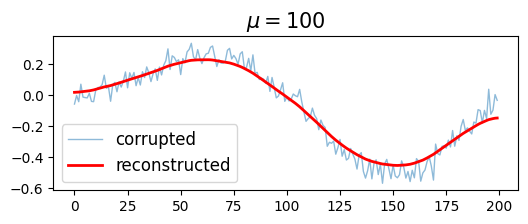

```python
mu = 100

D = np.zeros([n-1, n])
D[:,0:n-1] -= np.eye(n-1)

D[:,1:n] += np.eye(n-1)
A = np.vstack([np.eye(n), np.sqrt(mu)*D])

b = np.vstack([x_cor, np.zeros([n-1,1])])

A = np.asmatrix(A)
b = np.asmatrix(b)

x_reconst = (A.T*A).I*A.T*b

plt.figure(figsize = (6, 2))
plt.plot(t, x_cor, '-', linewidth = 1, alpha = 0.5, label = 'corrupted');
plt.plot(t, x_reconst, 'r', linewidth = 2, label = 'reconstructed')
plt.title('$\mu = {}$'.format(mu), fontsize = 15)
plt.legend(fontsize = 12)
plt.show()
```

As demonstrated, the original signal can be effectively reconstructed from the corrupted one using regression techniques. While this process highlights the potential of regression for noise reduction, it is important to note that such tasks are typically achieved more effectively and efficiently using low-pass filters in either the time or frequency domain. Nevertheless, this example serves to highlight the broader applicability of regression methods, demonstrating their potential to address various practical problems.

Another important point is that this example emphasizes the importance of formulating problems in a form of a regression model, as it can provide valuable insights and effective solutions even in contexts that may not initially seem related to regression models.

**Different $\mu$'s (See How $\mu$ Affects Smoothing Results)**

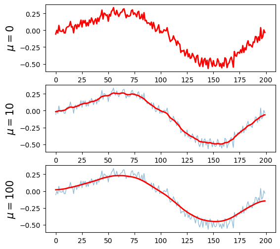

```python
plt.figure(figsize = (6, 6))

mu = [0, 10, 100];

for i in range(len(mu)):
    A = np.vstack([np.eye(n), np.sqrt(mu[i])*D])
    b = np.vstack([x_cor, np.zeros([n-1,1])])

    A = np.asmatrix(A)
    b = np.asmatrix(b)

    x_reconst = (A.T*A).I*A.T*b

    plt.subplot(3,1,i+1)
    plt.plot(t, x_cor, '-', linewidth = 1, alpha = 0.5)
    plt.plot(t, x_reconst, 'r', linewidth = 2)
    plt.ylabel('$\mu = {}$'.format(mu[i]), fontsize = 15)

plt.show()
```

### 5.1.1. CVXPY Implementation

To solve the denoising optimization problem numerically, we can use the `cvxpy` library:

$$\min_{X}\;\lVert(X - X_{\text{cor}})\rVert^2_{2} + \mu\sum_{k = 1}^{n-1}(x_{k+1}-x_{k})^2$$

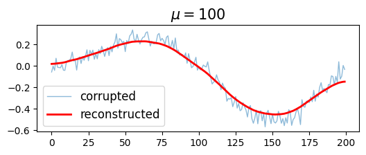

```python
mu = 100

x_reconst = cvx.Variable([n,1])
obj = cvx.Minimize(cvx.sum_squares(x_reconst - x_cor) + mu*cvx.sum_squares(x_reconst[1:n]-x_reconst[0:n-1]))
# obj = cvx.Minimize(cvx.sum_squares(x_reconst - x_cor) + mu*cvx.sum_squares(D@x_reconst))

prob = cvx.Problem(obj).solve()

plt.figure(figsize = (6, 2))
plt.plot(t, x_cor, '-', linewidth = 1, alpha = 0.5, label = 'corrupted');
plt.plot(t, x_reconst.value, 'r', linewidth = 2, label = 'reconstructed')
plt.title('$\mu = {}$'.format(mu), fontsize = 15)
plt.legend(fontsize = 12)
plt.show()
```

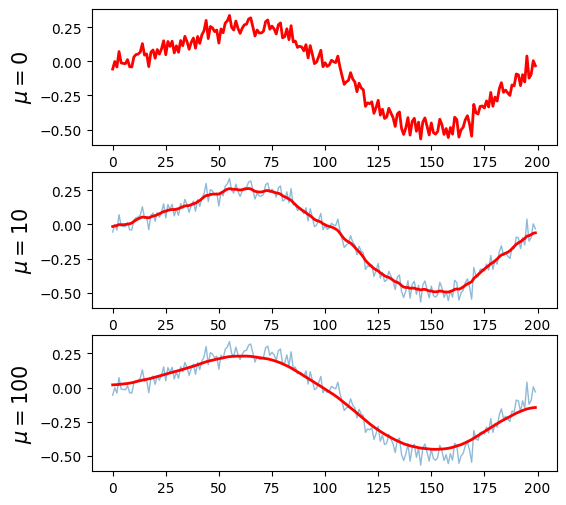

```python
plt.figure(figsize = (6, 6))

mu = [0, 10, 100]

for i in range(len(mu)):
    x_reconst = cvx.Variable([n,1])
    obj = cvx.Minimize(cvx.sum_squares(x_reconst - x_cor) + mu[i]*cvx.sum_squares(D @ x_reconst))
    prob = cvx.Problem(obj).solve()

    plt.subplot(3,1,i+1)
    plt.plot(t,x_cor,'-', linewidth = 1, alpha = 0.5)
    plt.plot(t,x_reconst.value, 'r', linewidth = 2)
    plt.ylabel('$\mu = {}$'.format(int(mu[i])), fontsize = 15)

plt.show()
```

### 5.1.2. L2 Norm

CVXPY strongly encourages the use of norm expressions (like `cvx.norm`) over explicit quadratic forms such as:

- `cvx.sum_squares()`
- `cvx.sum(cp.square())`
- `cvx.quad_form()`

This is because norms are convex, efficient, and automatically handled under CVXPY's disciplined convex programming (DCP) rules.

Preferred Objective Form:

$$ \min \; \left\{ \lVert X - X_{\text{cor}}\rVert_2 + \gamma \lVert DX \rVert_2 \right \}$$

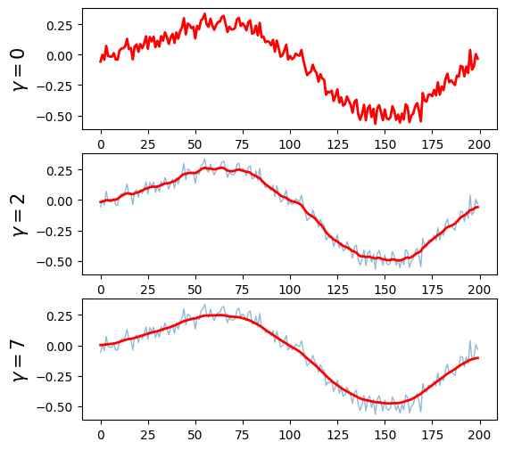

```python
plt.figure(figsize = (6, 6))

gammas = [0, 2, 7]

for i in range(len(gammas)):
    x_reconst = cvx.Variable([n,1])
    obj = cvx.Minimize(cvx.norm(x_reconst-x_cor, 2) + gammas[i]*(cvx.norm(D @ x_reconst, 2)))
    prob = cvx.Problem(obj).solve()

    plt.subplot(3,1,i+1)
    plt.plot(t,x_cor,'-', linewidth = 1, alpha = 0.5)
    plt.plot(t,x_reconst.value, 'r', linewidth = 2)
    plt.ylabel('$ \gamma = {}$'.format(gammas[i]), fontsize = 15)

plt.show()
```

### 5.1.3. L2 Norm with a Constraint

Instead of combining the fidelity and smoothness terms in a single objective function, we can pose the problem as a constrained optimization

$$ \begin{align*} \min \quad & \lVert Dx \rVert_2 \\ \text{subject to} \quad & \lVert x-x_{\text{cor}} \rVert_2 \leq \beta \end{align*} $$

Where

- The objective function $ \lVert D x \rVert_2 $ encourages smoothness in the recovered signal.
- The constraint $ \lVert x - x_{\text{cor}} \rVert_2 < \beta $ ensures that the denoised signal doesn't deviate too far from the observed noisy input.
- The parameter $ \beta $ sets a tolerance level for how much deviation is acceptable.

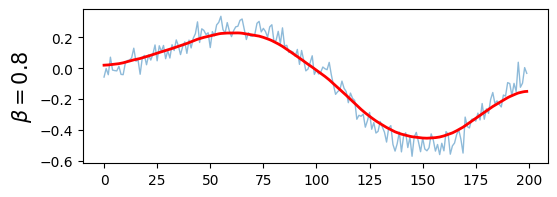

```python
beta = 0.8

x_reconst = cvx.Variable([n,1])
obj = cvx.Minimize(cvx.norm(D @ x_reconst, 2))
const = [cvx.norm(x_reconst-x_cor, 2) <= beta]
prob = cvx.Problem(obj, const).solve()

plt.figure(figsize = (6, 2))
plt.plot(t,x_cor,'-', linewidth = 1, alpha = 0.5)
plt.plot(t,x_reconst.value, 'r', linewidth = 2)
plt.ylabel(r'$\beta = {}$'.format(beta), fontsize = 15)
plt.show()
```

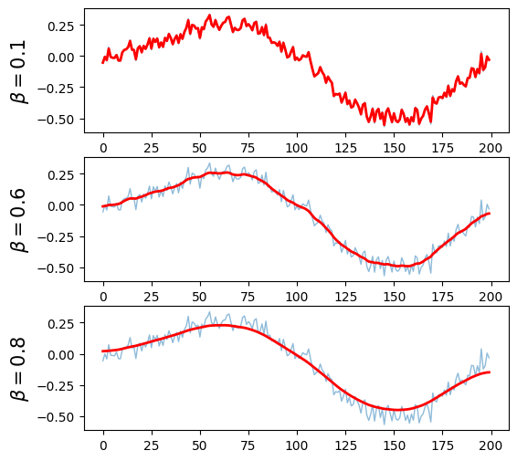

```python
plt.figure(figsize = (6, 6))

beta = [0.1, 0.6, 0.8]

for i in range(len(beta)):

    x_reconst = cvx.Variable([n,1])
    obj = cvx.Minimize(cvx.norm(x_reconst[1:n] - x_reconst[0:n-1], 2))
    const = [cvx.norm(x_reconst-x_cor, 2) <= beta[i]]
    prob = cvx.Problem(obj, const).solve()

    plt.subplot(len(beta),1,i+1)
    plt.plot(t,x_cor,'-', linewidth = 1, alpha = 0.5)
    plt.plot(t,x_reconst.value, 'r', linewidth = 2)
    plt.ylabel(r'$\beta = {}$'.format(beta[i]), fontsize = 15)

plt.show()
```

## 5.2. Signal with Sharp Transition + Noise

The previous example demonstrated that the optimization techniques we learned from linear regression can also be effectively applied to the problem of denoising continuous and corrupted signals.

Now, suppose we are dealing with a signal $x$ that is mostly smooth, but contains a few sharp transitions - such as sudden jumps or step-like changes. These are common in real-world signals, such as changes in system states, edges in images, or abrupt shifts in sensor readings.

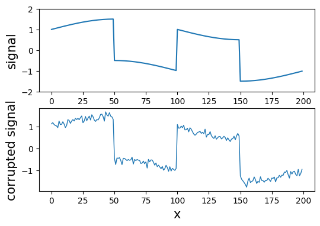

```python
n = 200
t = np.arange(n).reshape(-1,1)

exact = np.vstack([np.ones([50,1]), -np.ones([50,1]), np.ones([50,1]), -np.ones([50,1])])
x = exact + 0.5*np.sin((2*np.pi/n)*t)
x_cor = x + 0.1*np.random.randn(n,1)

plt.figure(figsize = (6, 4))
plt.subplot(2,1,1)
plt.plot(t, x)
plt.ylim([-2.0,2.0])
plt.ylabel('signal', fontsize = 15)
plt.subplot(2,1,2)
plt.plot(t, x_cor, linewidth = 1)
plt.ylabel('corrupted signal', fontsize = 15)
plt.xlabel('x', fontsize = 15)
plt.show()
```

### 5.2.1. L2 Norm (Quadratic Smoothing)

Let's start by applying the same L2-based smoothing technique used before. We'll observe how it performs when the underlying signal includes sharp transitions.

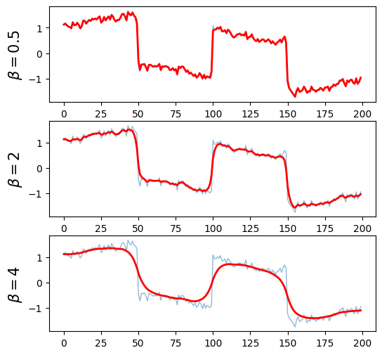

```python
plt.figure(figsize = (6, 6))

beta = [0.5, 2, 4]

for i in range(len(beta)):
    x_reconst = cvx.Variable([n,1])
    obj = cvx.Minimize(cvx.norm(x_reconst[1:n] - x_reconst[0:n-1], 2))
    const = [cvx.norm(x_reconst - x_cor, 2) <= beta[i]]
    prob = cvx.Problem(obj, const).solve()

    plt.subplot(len(beta), 1, i+1)
    plt.plot(t, x_cor, linewidth = 1, alpha = 0.5)
    plt.plot(t, x_reconst.value, 'r', linewidth = 2)
    plt.ylabel(r'$\beta = {}$'.format(beta[i]), fontsize = 15)

plt.show()
```

Quadratic smoothing (L2 norm panalty) smooths out *noise and sharp transitions* in signal, but this is not what we want.

**Why?**

If we apply the same quadratic smoothing method (based on the L2 norm of differences between adjacent points), we will indeed reduce noise. However, this method also tends to:

- Smooth out the sharp transitions in the signal
- Blur the regions that should remain distinct
- Fail to capture important structural information

This is because the quadratic penalty strongly discourages large differences between adjacent values, regardless of whether those differences are due to noise or actual signal features.

### 5.2.2. L1 Norm

We can instead apply L1 norm on the signal by solving

$$\min \; \lVert X - X_{\text{cor}} \rVert_2 + \lambda \sum_{i=1}^{n-1} \;\lvert x_{i+1}-x_i \rvert $$

Where

- The first term ensures the denoised signal stays close to the corrupted signal.
- The second term enforces sparsity in differences, encouraging flat regions and allowing for a few sharp changes.
- The regularization parameter $\lambda$ controls the balance between data fidelity and smoothness.

An alternative form focuses on enforcing a hard constraint on data fidelity, while minimizing total variation:

$$ \begin{align*} \min \quad & \lVert DX \rVert_{\color{red} 1} \\ \text{subject to} \quad & \lVert X - X_{\text{cor}} \rVert_2 < \beta \end{align*} $$

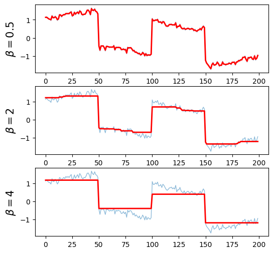

```python
plt.figure(figsize = (6, 6))

beta = [0.5, 2, 4]

for i in range(len(beta)):
    x_reconst = cvx.Variable([n,1])
    obj = cvx.Minimize(cvx.norm(x_reconst[1:n] - x_reconst[0:n-1], 1))
    const = [cvx.norm(x_reconst-x_cor, 2) <= beta[i]]
    prob = cvx.Problem(obj, const).solve()

    plt.subplot(len(beta), 1, i+1)
    plt.plot(t, x_cor, linewidth = 1, alpha = 0.5)
    plt.plot(t, x_reconst.value, 'r', linewidth = 2)
    plt.ylabel(r'$\beta = {}$'.format(beta[i]), fontsize = 15)

plt.show()
```

Consider the results presented above and reflect on why they behave the way they do.

**Total Variation (TV) Smoothing**

Total Variation (TV) smoothing is a powerful and widely used technique in signal and image processing. Its goal is to reduce noise while preserving important structural details - especially sharp transitions, such as edges or abrupt changes in the signal.

Unlike traditional smoothing methods (e.g., those based on the L2 norm), which often introduce unwanted blurring across the entire signal, TV smoothing excels at maintaining sharp features while still achieving effective denoising.

**Why TV Works Well for Sharp Transitions**

One of the most notable strengths of TV smoothing is its ability to preserve discontinuities in the data:

- In image processing: TV helps maintain edges, where pixel intensities change suddenly.
- In time-series or 1D signals: It retains jumps or step-like behaviors, which might represent important events or transitions.

This is possible because TV denoising uses L1 regularization on signal differences, which:

- Penalizes large changes, but less aggressively than the L2 norm
- Encourages sparsity in the derivative (i.e., most differences are zero, but a few sharp jumps are allowed)

By balancing noise reduction with the preservation of sharp transitions, TV smoothing provides a practical and robust solution for many real-world denoising problems.

# 6. Example: Total Variation Image Reconstruction

In this final example, we apply Total Variation (TV) smoothing to an image - a practical demonstration of how regression principles can extend beyond standard prediction tasks into areas like image denoising and signal reconstruction.

- Idea comes from [here](https://drive.google.com/file/d/1vWxv5JeJ21_mddFCsUEHJhIc7mKiJ1Cd/view?usp=sharing)
- Download [the image](https://drive.google.com/file/d/1vWxv5JeJ21_mddFCsUEHJhIc7mKiJ1Cd/view?usp=sharing)

```python
from google.colab import drive
drive.mount('/content/drive')
```

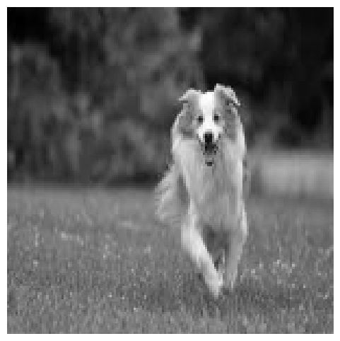

```python
import cv2

imbw = cv2.imread('/content/drive/MyDrive/ML/ML_data/dog.jpg', 0)

row = 150
col = 150
resized_imbw = cv2.resize(imbw, (row, col))

plt.figure(figsize = (6, 6))
plt.imshow(resized_imbw, 'gray')
plt.axis('off')
plt.show()
```

Question: What kind of image do you expect if we apply an L1 norm on the image gradients?

$$ \begin{align*} \min \quad & \lVert DX \rVert_{\color{red} 1} \\ \text{subject to} \quad & \lVert X - X_{\text{cor}} \rVert_2 < \beta \end{align*} $$

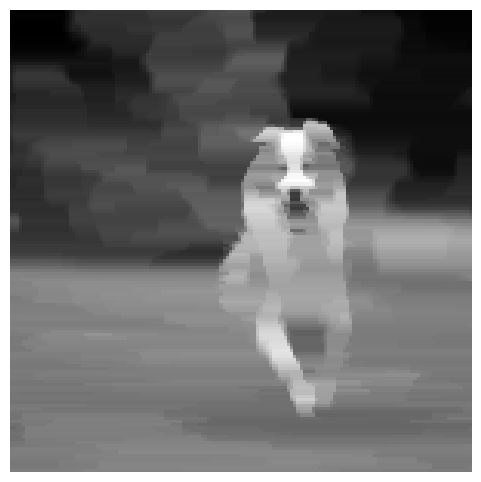

```python
n = row*col
imbws = resized_imbw.reshape(-1, 1)

beta = 1500

x = cvx.Variable([n,1])
obj = cvx.Minimize(cvx.norm(x[1:n] - x[0:n-1],1))
const = [cvx.norm(x - imbws,2) <= beta]
prob = cvx.Problem(obj, const).solve()

imbwr = x.value.reshape(row, col)

plt.figure(figsize = (6, 6))
plt.imshow(imbwr,'gray')
plt.axis('off')
plt.show()
```

Applying this optimization yields an image that is:

- Denoised, with noise and small pixel variations suppressed
- Sharp, as edges and contours are preserved
- Piecewise smooth, with flat regions where possible and sharp transitions where necessary

This example demonstrates how regression principles extend beyond conventional predictive models and can be applied effectively to complex tasks such as image denoising and signal reconstruction.

```python
%%javascript
$.getScript('https://kmahelona.github.io/ipython_notebook_goodies/ipython_notebook_toc.js')
```